# Working with the Cal-Adapt API in R

Andy Lyons

7/22/2019

# Goals of the `caladaptr` R Package

`caladaptr` will be an API client package.

The intended audience is developers.

Primary role is to provide low-level functions for querying and importing Cal-Adapt data through the API.

Secondary roles might be computing generic derived dataset not yet available on the API (e.g., chill hours).

Enable light-weight decision support tools through RShiny that present Cal-Adapt data in user friendly terminology, combine with other datasets, produce user friendly output, etc.

# Example Applications

My Ranch Climate History

Landscaping Species Selection

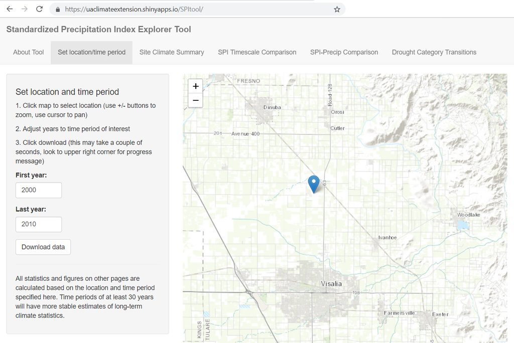

(https://uaclimateextension.shinyapps.io/SPItool/)

# Development Plans

Build it on GitHub

Submit to [ROpenSci](https://ropensci.org/) for peer reivew

Follow the guideslines and best practices for package development: https://devguide.ropensci.org/

Convert spatial data as `raster` and `sf` objects

Incorporate `tidyverse` piping syntax (i.e., build queries with `%>%` operators)

Main dependencies: `httr`, `sf`

Working list of functions

- `ca_resources()` - names of raster series, individual rasters
- `ca_getraster()` - import raster(s)
- `ca_qryraster()` - query raster(s)

# API Terminology

**RESOURCES**. We refer to the *datasets* in the Cal-Adapt API as *resources*. Each resource is represented by a unique endpoint (URL). Names of resources: https://berkeley-gif.github.io/caladapt-docs/data-catalog.html

**RASTER SERIES**. A *Raster Series* is a collection of individual rasters comprising an entire time series.

**RASTER STORE**. A *Raster Store* is an individual raster file and associated information like spatial resolution, coordinate system reference, and bounding box.

**SLUGS**. A slug is a *URL friendly* name of a resource in the API. Each climate dataset or resource has it’s own unique slug. A resource slug is generally composed of {variable}*{period}*{model}_{scenario}. Request an individual series with a provided slug.

Resource URI Example: `https://api.cal-adapt.org/api/series/tasmax_year_livneh/`

# Searching for Data

```r
ca_base_url <- "http://api.cal-adapt.org/api/"   ## turn this into a function
```

**Question for S&B**: http or https?

```r
## Request resources (datasets)
ca_resources_resp <- httr::GET(ca_base_url)
class(ca_resources_resp)
```

```
## [1] "response"
```

```r
## Trap response problems
## Stop everything for a return code >= 400
msg_code400 <- "Server returned an error code. Check your request."
assert_that(ca_resources_resp$status_code < 400, msg = msg_code400)
```

```
## [1] TRUE
```

```r
## Give a warning for other things
warn_for_status(ca_resources_resp, task = "retrieve list of resources")

## Parse the response object into a list
ca_resources_data <- httr::content(ca_resources_resp, type = "application/json")
class(ca_resources_data)
```

```
## [1] "list"
```

```r
names(ca_resources_data)
```

```
##  [1] "ccc4aregions"      "cdistricts"        "censustracts"
##  [4] "climregions"       "counties"          "datasets"
##  [7] "electricutilities" "evtlocations"      "hydrounits"
## [10] "irwm"              "locagrid"          "place"
## [13] "rstores"           "series"            "tseries"
## [16] "wecc-load-area"
```

```r
ca_resources_data$series
```

```
## [1] "https://api.cal-adapt.org/api/series/"
```

# Get Details about available Raster Series

```r
(url_series_all <- paste0(ca_base_url, "series", "/"))
```

```
## [1] "http://api.cal-adapt.org/api/series/"
```

```r
qry_params_lst <- list(pagesize=100)

ca_rstseries_resp <- httr::GET(url_series_all, query=qry_params_lst, httr::content_type_json())

## Trap response problems
assert_that(ca_resources_resp$status_code < 400, msg=msg_code400)
```

```
## [1] TRUE
```

```r
warn_for_status(ca_resources_resp, task = "retrieve list of resources")

## Convert response to a list
ca_rstseries_data <- httr::content(ca_rstseries_resp, type = "application/json")

## Explore list
names(ca_rstseries_data)
```

```
## [1] "count"    "next"     "previous" "results"
```

```r
ca_rstseries_data$count
```

```
## [1] 390
```

```r
ca_rstseries_data[["next"]]
```

```
## [1] "https://api.cal-adapt.org/api/series/?page=2&pagesize=100"
```

```r
ca_rstseries_data[["previous"]]
```

```r
class(ca_rstseries_data[["results"]])
```

```
## [1] "list"
```

```r
names(ca_rstseries_data[["results"]])  ## no names
```

```r
length(ca_rstseries_data[["results"]])
```

```
## [1] 100
```

```r
class(ca_rstseries_data[["results"]][[1]])
```

```
## [1] "list"
```

```r
names(ca_rstseries_data[["results"]][[1]])
```

```
## [1] "name"    "slug"    "url"     "begin"   "end"     "rasters" "tres"
```

```r
ca_rstseries_data[["results"]][[1]]$name
```

```
## [1] "LOCA VIC drought daily baseflow HadGEM2-ES RCP 8.5 early century"
```

```r
## Return the names of the datasets in this object
sapply(ca_rstseries_data[["results"]], function(x) x$name )
```

```
##   [1] "LOCA VIC drought daily baseflow HadGEM2-ES RCP 8.5 early century"
##   [2] "LOCA VIC drought daily baseflow HadGEM2-ES RCP 8.5 late century"
##   [3] "Livneh VIC daily baseflow"
##   [4] "LOCA VIC maximum 32 models water year baseflow RCP 8.5"
##   [5] "LOCA VIC minimum 32 models water year baseflow RCP 8.5"
##   [6] "LOCA VIC maximum 32 models baseflow RCP 8.5"
##   [7] "LOCA VIC minimum 32 models baseflow RCP 8.5"
##   [8] "LOCA VIC drought daily evapotranspiration HadGEM2-ES RCP 8.5 early century"
##   [9] "LOCA VIC drought daily evapotranspiration HadGEM2-ES RCP 8.5 late century"
##  [10] "Livneh VIC daily evapotranspiration"
##  [11] "LOCA VIC maximum 32 models water year evapotranspiration RCP 8.5"
##  [12] "LOCA VIC minimum 32 models water year evapotranspiration RCP 8.5"
##  [13] "LOCA VIC maximum 32 models evapotranspiration RCP 8.5"
##  [14] "LOCA VIC minimum 32 models evapotranspiration RCP 8.5"
##  [15] "U.C. Merced Wildfire yearly high population scenario CNRM-CM5 RCP 4.5"
```

[output cut: 85 more lines]

```r
## Return the slugs of the datasets in this object
sapply(ca_rstseries_data[["results"]], function(x) x$slug)
```

```
##   [1] "baseflow_day_drought_HadGEM2-ES_rcp85_early_century"
##   [2] "baseflow_day_drought_HadGEM2-ES_rcp85_late_century"
##   [3] "baseflow_day_livneh_vic"
##   [4] "baseflow_wateryear_vic_models-max_rcp85"
##   [5] "baseflow_wateryear_vic_models-min_rcp85"
##   [6] "baseflow_year_vic_models-max_rcp85"
##   [7] "baseflow_year_vic_models-min_rcp85"
##   [8] "et_day_drought_HadGEM2-ES_rcp85_early_century"
##   [9] "et_day_drought_HadGEM2-ES_rcp85_late_century"
##  [10] "et_day_livneh_vic"
##  [11] "et_wateryear_vic_models-max_rcp85"
##  [12] "et_wateryear_vic_models-min_rcp85"
##  [13] "et_year_vic_models-max_rcp85"
##  [14] "et_year_vic_models-min_rcp85"
##  [15] "fire_CNRM-CM5_rcp45_H_mu"
```

[output cut: 85 more lines]

**Question for S&B**: Are the names & slugs of resources stable? (i.e., can we save them as part of the package?)

Does each Raster Series have a help page?

# Search for Resource by Name

```r
(url_series_all <- paste0(ca_base_url, "series", "/"))
```

```
## [1] "http://api.cal-adapt.org/api/series/"
```

```r
qry_params_lst <- list(name="yearly average maximum temperature", pagesize=100)

# Submit request
rs_maxtemp_resp <- httr::GET(url_series_all, query=qry_params_lst, httr::content_type_json())

## Trap response problems
assert_that(rs_maxtemp_resp$status_code < 400, msg=msg_code400)
```

```
## [1] TRUE
```

```r
warn_for_status(rs_maxtemp_resp, task = "retrieve list of resources matching name")

## Convert response to a list
rs_maxtemp_data <- httr::content(rs_maxtemp_resp, type = "application/json")

## Check for no results
rs_maxtemp_data$count
```

```
## [1] 31
```

```r
if (rs_maxtemp_data$count==0) warning("No results returned from query")
#assert_that(ca_precip3_data$count > 0)

## List names and URLs returned
sapply(rs_maxtemp_data$results, function(x) x$slug)
```

```
##  [1] "tasmax_year_ACCESS1-0_historical"
##  [2] "tasmax_year_ACCESS1-0_rcp45"
##  [3] "tasmax_year_ACCESS1-0_rcp85"
##  [4] "tasmax_year_CCSM4_historical"
##  [5] "tasmax_year_CCSM4_rcp45"
##  [6] "tasmax_year_CCSM4_rcp85"
##  [7] "tasmax_year_CESM1-BGC_historical"
##  [8] "tasmax_year_CESM1-BGC_rcp45"
##  [9] "tasmax_year_CESM1-BGC_rcp85"
## [10] "tasmax_year_CMCC-CMS_historical"
## [11] "tasmax_year_CMCC-CMS_rcp45"
## [12] "tasmax_year_CMCC-CMS_rcp85"
## [13] "tasmax_year_CNRM-CM5_historical"
## [14] "tasmax_year_CNRM-CM5_rcp45"
## [15] "tasmax_year_CNRM-CM5_rcp85"
```

[output cut: 16 more lines]

# Get the metadata details for a specific Raster Series

```r
rseries_slug <- "tasmax_year_CNRM-CM5_rcp45"
(rseries_url <- paste0(ca_base_url, "series", "/", rseries_slug, "/"))
```

```
## [1] "http://api.cal-adapt.org/api/series/tasmax_year_CNRM-CM5_rcp45/"
```

```r
qry_params_lst <- list(pagesize=100)

# Submit request
rseries_tmax_resp <- httr::GET(rseries_url, query=qry_params_lst, httr::content_type_json())

## Trap response problems
assert_that(rseries_tmax_resp$status_code < 400, msg=msg_code400)
```

```
## [1] TRUE
```

```r
warn_for_status(rseries_tmax_resp, task = "retrieve metadata for a raster series")

## Convert response to a list
rseries_tmax_data <- httr::content(rseries_tmax_resp, type = "application/json")

## Explore results
class(rseries_tmax_data)
```

```
## [1] "list"
```

```r
names(rseries_tmax_data)
```

```
## [1] "name"    "slug"    "url"     "begin"   "end"     "rasters" "tres"
```

```r
rseries_tmax_data$name
```

```
## [1] "LOCA yearly average maximum temperature CNRM-CM5 RCP 4.5"
```

```r
rseries_tmax_data$slug; rseries_tmax_data$url
```

```
## [1] "tasmax_year_CNRM-CM5_rcp45"
```

```
## [1] "https://api.cal-adapt.org/api/series/tasmax_year_CNRM-CM5_rcp45/"
```

```r
rseries_tmax_data$begin; rseries_tmax_data$end
```

```
## [1] "2006-01-01T00:00:00Z"
```

```
## [1] "2100-12-31T00:00:00Z"
```

```r
## Convert begin and end values to R objects (POSIXlt)
(begin_dte <- strptime(rseries_tmax_data$begin, format="%Y-%m-%dT%T", tz="UTC"))
```

```
## [1] "2006-01-01 UTC"
```

```r
(end_dte <- strptime(rseries_tmax_data$end, format="%Y-%m-%dT%T", tz="UTC"))
```

```
## [1] "2100-12-31 UTC"
```

```r
## How to check for no results??

## View rasters in this Raster Series
length(rseries_tmax_data$rasters)
```

```
## [1] 95
```

```r
sapply(rseries_tmax_data$rasters, function(x) x[1])
```

```
##  [1] "https://api.cal-adapt.org/api/rstores/tasmax_year_CNRM-CM5_rcp45_2006/"
##  [2] "https://api.cal-adapt.org/api/rstores/tasmax_year_CNRM-CM5_rcp45_2007/"
##  [3] "https://api.cal-adapt.org/api/rstores/tasmax_year_CNRM-CM5_rcp45_2008/"
##  [4] "https://api.cal-adapt.org/api/rstores/tasmax_year_CNRM-CM5_rcp45_2009/"
##  [5] "https://api.cal-adapt.org/api/rstores/tasmax_year_CNRM-CM5_rcp45_2010/"
##  [6] "https://api.cal-adapt.org/api/rstores/tasmax_year_CNRM-CM5_rcp45_2011/"
##  [7] "https://api.cal-adapt.org/api/rstores/tasmax_year_CNRM-CM5_rcp45_2012/"
##  [8] "https://api.cal-adapt.org/api/rstores/tasmax_year_CNRM-CM5_rcp45_2013/"
##  [9] "https://api.cal-adapt.org/api/rstores/tasmax_year_CNRM-CM5_rcp45_2014/"
## [10] "https://api.cal-adapt.org/api/rstores/tasmax_year_CNRM-CM5_rcp45_2015/"
## [11] "https://api.cal-adapt.org/api/rstores/tasmax_year_CNRM-CM5_rcp45_2016/"
## [12] "https://api.cal-adapt.org/api/rstores/tasmax_year_CNRM-CM5_rcp45_2017/"
## [13] "https://api.cal-adapt.org/api/rstores/tasmax_year_CNRM-CM5_rcp45_2018/"
## [14] "https://api.cal-adapt.org/api/rstores/tasmax_year_CNRM-CM5_rcp45_2019/"
## [15] "https://api.cal-adapt.org/api/rstores/tasmax_year_CNRM-CM5_rcp45_2020/"
```

[output cut: 80 more lines]

**Question for S&B**: ‘Begin’ and ‘End’ values for raster series look like: “`2006-01-01T00:00:00Z”`

Are there ever *time values* associated with ‘begin’ and ‘end’ values of a Raster Series?

# Get Info about a Raster Store Object

```r
## First we view the raster store objects
rseries_slug <- "tasmax_year_CNRM-CM5_rcp45"
(rstore_list_url <- paste0(ca_base_url, "series", "/", rseries_slug, "/", "rasters", "/"))
```

```
## [1] "http://api.cal-adapt.org/api/series/tasmax_year_CNRM-CM5_rcp45/rasters/"
```

```r
qry_params_lst <- list(pagesize=100)

# Submit request
rstore_list_resp <- httr::GET(rstore_list_url, query=qry_params_lst, httr::content_type_json())

## Trap response problems
assert_that(rstore_list_resp$status_code < 400, msg=msg_code400)
```

```
## [1] TRUE
```

```r
warn_for_status(rstore_list_resp, task = "retrieve metadata for a raster series")

## Convert response to a list
rstore_list_data <- httr::content(rstore_list_resp, type = "application/json")

## Explore results
names(rstore_list_data)
```

```
## [1] "count"    "next"     "previous" "results"
```

```r
rstore_list_data$count
```

```
## [1] 95
```

```r
class(rstore_list_data$results)
```

```
## [1] "list"
```

```r
length(rstore_list_data$results)
```

```
## [1] 95
```

```r
## Look at one of the results
class(rstore_list_data$results[[1]])
```

```
## [1] "list"
```

```r
names(rstore_list_data$results[[1]])
```

```
##  [1] "id"       "tileurl"  "url"      "image"    "width"    "height"
##  [7] "geom"     "event"    "srs"      "minval"   "maxval"   "nodata"
## [13] "xpixsize" "ypixsize" "name"     "slug"     "units"
```

```r
## Look at the tile URL
rstore_list_data$results[[1]]$tileurl
```

```
## [1] "https://api.cal-adapt.org/tiles/tasmax_year_CNRM-CM5_rcp45_2006/{z}/{x}/{y}.png"
```

**Question for S&B**: can we use a Cal-Adapt tiles in a leaflet map?

```r
rstore_list_data$results[[1]]$units
```

```
## [1] "K"
```

```r
rstore_list_data$results[[1]]$xpixsize
```

```
## [1] 0.0625
```

```r
## Look at the geom (which in this case is the extent of the raster)
(tif_bb_lst <- rstore_list_data$results[[1]]$geom)
```

```
## $type
## [1] "Polygon"
##
## $coordinates
## $coordinates[[1]]
## $coordinates[[1]][[1]]
## $coordinates[[1]][[1]][[1]]
## [1] -124.5625
##
## $coordinates[[1]][[1]][[2]]
## [1] 31.5625
##
##
## $coordinates[[1]][[2]]
## $coordinates[[1]][[2]][[1]]
## [1] -113.375
##
## $coordinates[[1]][[2]][[2]]
## [1] 31.5625
##
##
## $coordinates[[1]][[3]]
## $coordinates[[1]][[3]][[1]]
## [1] -113.375
##
## $coordinates[[1]][[3]][[2]]
## [1] 43.75
##
##
## $coordinates[[1]][[4]]
## $coordinates[[1]][[4]][[1]]
## [1] -124.5625
##
## $coordinates[[1]][[4]][[2]]
## [1] 43.75
##
##
## $coordinates[[1]][[5]]
## $coordinates[[1]][[5]][[1]]
## [1] -124.5625
##
## $coordinates[[1]][[5]][[2]]
## [1] 31.5625
```

```r
class(tif_bb_lst)
```

```
## [1] "list"
```

```r
length(tif_bb_lst)
```

```
## [1] 2
```

```r
names(tif_bb_lst)
```

```
## [1] "type"        "coordinates"
```

```r
tif_bb_lst$type
```

```
## [1] "Polygon"
```

```r
str(tif_bb_lst$coordinates)
```

```
## List of 1
##  $ :List of 5
##   ..$ :List of 2
##   .. ..$ : num -125
##   .. ..$ : num 31.6
##   ..$ :List of 2
##   .. ..$ : num -113
##   .. ..$ : num 31.6
##   ..$ :List of 2
##   .. ..$ : num -113
##   .. ..$ : num 43.8
##   ..$ :List of 2
##   .. ..$ : num -125
##   .. ..$ : num 43.8
##   ..$ :List of 2
##   .. ..$ : num -125
##   .. ..$ : num 31.6
```

**Puzzle**: how to work with geom objects returned from the API.

Has to do with how `httr::content()` converts GeoJSON objects to nested lists of coordinates.

# Import a Raster

```r
## Get the URL for the first GeoTIFF
(tif_url <- rstore_list_data$results[[1]]$image)
```

```
## [1] "https://api.cal-adapt.org/media/img/tasmax_year_CNRM-CM5_rcp45_r1i1p1_2006.LOCA_2016-04-02.16th.CA_NV.tif"
```

```r
class(tif_url)
```

```
## [1] "character"
```

```r
library(raster)
this_img_ll <- raster::raster(tif_url)
this_img_ll
```

```
## class      : RasterLayer
## dimensions : 195, 179, 34905  (nrow, ncol, ncell)
## resolution : 0.0625, 0.0625  (x, y)
## extent     : -124.5625, -113.375, 31.5625, 43.75  (xmin, xmax, ymin, ymax)
## crs        : +proj=longlat +datum=WGS84 +no_defs +ellps=WGS84 +towgs84=0,0,0
## source     : https://api.cal-adapt.org/media/img/tasmax_year_CNRM-CM5_rcp45_r1i1p1_2006.LOCA_2016-04-02.16th.CA_NV.tif
## names      : tasmax_year_CNRM.CM5_rcp45_r1i1p1_2006.LOCA_2016.04.02.16th.CA_NV
```

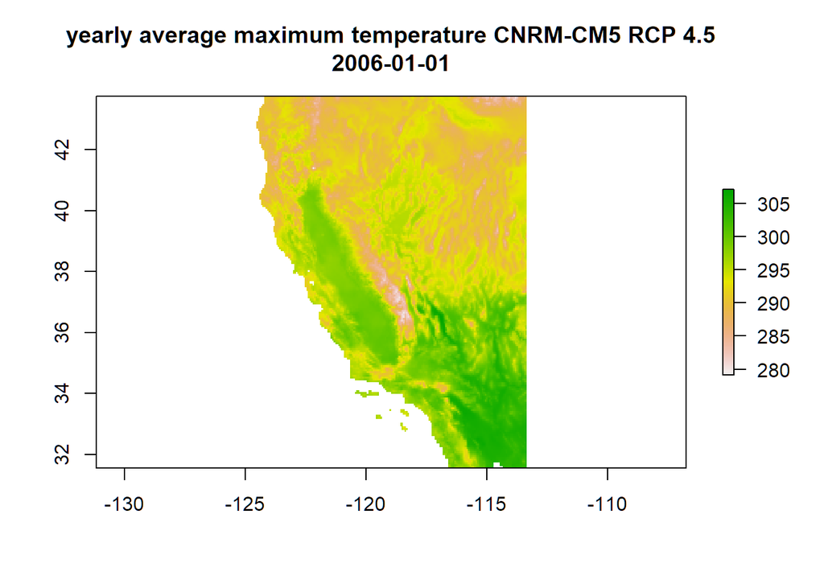

```r
plot(this_img_ll, main=paste0(rstore_list_data$results[[1]]$name, "\n", rstore_list_data$results[[1]]$event))
```

**Question for S&B**: Is there a crop option?

# Import a Raster Stack

```r
(tif_url <- sapply(rstore_list_data$results[1:3], function(x) x$image))
```

```
## [1] "https://api.cal-adapt.org/media/img/tasmax_year_CNRM-CM5_rcp45_r1i1p1_2006.LOCA_2016-04-02.16th.CA_NV.tif"
## [2] "https://api.cal-adapt.org/media/img/tasmax_year_CNRM-CM5_rcp45_r1i1p1_2007.LOCA_2016-04-02.16th.CA_NV.tif"
## [3] "https://api.cal-adapt.org/media/img/tasmax_year_CNRM-CM5_rcp45_r1i1p1_2008.LOCA_2016-04-02.16th.CA_NV.tif"
```

```r
first_three_imgs <- raster::stack(tif_url)
first_three_imgs
```

```
## class      : RasterStack
## dimensions : 195, 179, 34905, 3  (nrow, ncol, ncell, nlayers)
## resolution : 0.0625, 0.0625  (x, y)
## extent     : -124.5625, -113.375, 31.5625, 43.75  (xmin, xmax, ymin, ymax)
## crs        : +proj=longlat +datum=WGS84 +no_defs +ellps=WGS84 +towgs84=0,0,0
## names      : tasmax_year_CNRM.CM5_rcp45_r1i1p1_2006.LOCA_2016.04.02.16th.CA_NV, tasmax_year_CNRM.CM5_rcp45_r1i1p1_2007.LOCA_2016.04.02.16th.CA_NV, tasmax_year_CNRM.CM5_rcp45_r1i1p1_2008.LOCA_2016.04.02.16th.CA_NV
```

# Query a Point Location

```r
## Get a Point
pt <- c(-121.4687,38.5938)

## We use the sf package to convert the point to WKT
library(sf)
(pt_wkt <- st_as_text(st_point(pt)))
```

```
## [1] "POINT (-121.4687 38.5938)"
```

```r
qry_params_lst <- list(pagesize=10, g=pt_wkt)

## As an alternative, we could convert the point to JSON
pt2json <- function(pt) {
  return(paste0("{\"type\":\"Point\",\"coordinates\":[", pt[1], ",", pt[2], "]}")  )
}
(pt_json <- pt2json(pt))
```

```
## [1] "{\"type\":\"Point\",\"coordinates\":[-121.4687,38.5938]}"
```

```r
## Construct URL
rseries_slug <- "tasmax_year_CNRM-CM5_rcp45"
(rstore_list_url <- paste0(ca_base_url, "series", "/", rseries_slug, "/", "rasters", "/"))
```

```
## [1] "http://api.cal-adapt.org/api/series/tasmax_year_CNRM-CM5_rcp45/rasters/"
```

```r
## Make request
rstore_qrypt_resp <- httr::GET(rstore_list_url, query=qry_params_lst, content_type_json())

## Trap response problems
assert_that(rstore_qrypt_resp$status_code < 400, msg=msg_code400)
```

```
## [1] TRUE
```

```r
warn_for_status(rstore_qrypt_resp, task = "retrieve pixel values at a point")

## Convert response to a list
rstore_qrypt_data <- httr::content(rstore_qrypt_resp, type = "application/json")

## Explore results
names(rstore_qrypt_data)
```

```
## [1] "count"    "next"     "previous" "results"
```

```r
rstore_qrypt_data$count
```

```
## [1] 95
```

```r
length(rstore_qrypt_data$results)
```

```
## [1] 10
```

```r
names(rstore_qrypt_data$results[[1]])
```

```
##  [1] "id"       "tileurl"  "url"      "image"    "width"    "height"
##  [7] "geom"     "event"    "srs"      "minval"   "maxval"   "nodata"
## [13] "xpixsize" "ypixsize" "name"     "slug"     "units"
```

```r
## View Pixel Values at this Point
sapply(rstore_qrypt_data$results, function(x) x$image)
```

```
##  [1] 297.9866 297.7722 297.9955 297.1314 298.7227 297.8650 298.1152
##  [8] 298.7023 298.2465 297.0635
```

# Query a Raster Series with a User-Supplied Polygon and User-Supplied Date Range

```r
## Load the Yosemite boundary
(yose_bnd_sf <- sf::st_read(dsn="./data", layer="yosemite_bnd"))
```

```
## Simple feature collection with 1 feature and 11 fields
## geometry type:  POLYGON
## dimension:      XY
## bbox:           xmin: -119.8864 ymin: 37.4947 xmax: -119.1964 ymax: 38.18515
## epsg (SRID):    4326
## proj4string:    +proj=longlat +datum=WGS84 +no_defs
##   UNIT_CODE
## 1      YOSE
##                                                                             GIS_NOTES
## 1 Lands - http://landsnet.nps.gov/tractsnet/documents/YOSE/METADATA/yose_metadata.xml
##                UNIT_NAME  DATE_EDIT STATE REGION GNIS_ID     UNIT_TYPE
## 1 Yosemite National Park 2016-01-27    CA     PW  255923 National Park
##   CREATED_BY                                               METADATA
## 1      Lands http://nrdata.nps.gov/programs/Lands/YOSE_METADATA.xml
##   PARKNAME                       geometry
## 1 Yosemite POLYGON ((-119.8456 37.8327...
```

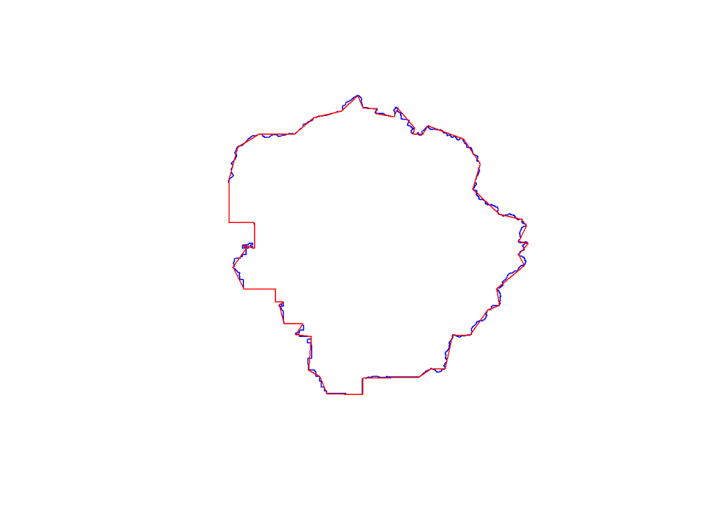

```r
## Simplify the to reduce the amount of data that needs to be passed to the server
## The dTolerance level is in map units, was identified through trial-and-error
yose_bnd_simp <- sf::st_simplify(yose_bnd_sf, dTolerance = 0.01)
## Plot the original and the simplified version
plot(st_geometry(yose_bnd_sf), asp=1, border="blue")
plot(st_geometry(yose_bnd_simp), border="red", add=TRUE)
```

```r
## Generate the WKT
yose_bnd_simp_wkt <- sf::st_as_text(yose_bnd_simp$geometry[1])
nchar(yose_bnd_simp_wkt)
```

```
## [1] 1093
```

```r
## Generate query parameters
(qry_params_lst <- list(pagesize=100, g=yose_bnd_simp_wkt, stat='mean'))
```

```
## $pagesize
## [1] 100
##
## $g
## [1] "POLYGON ((-119.8456 37.83278, -119.8548 37.84014, -119.827 37.83326, -119.8271 37.89242, -119.885 37.89177, -119.8863 37.98984, -119.866 38.06701, -119.8182 38.09569, -119.735 38.09628, -119.6907 38.13362, -119.6261 38.14972, -119.589 38.18514, -119.5765 38.15797, -119.5457 38.15478, -119.54…
##
## $stat
## [1] "mean"
```

Question for S&B: what happens if you omit ‘stat’?

```r
## Get the start and end dates as R objects
(begin_date <- as.Date("2050-01-01"))
```

```
## [1] "2050-01-01"
```

```r
(end_date <- as.Date("2060-12-31"))
```

```
## [1] "2060-12-31"
```

```r
begin_date < end_date
```

```
## [1] TRUE
```

```r
## Generate the URL, with the begin and end date
rseries_slug <- "tasmax_year_CNRM-CM5_rcp45"

(begin_end_url = paste0(ca_base_url, "series", "/", rseries_slug, "/", format(begin_date, "%Y-%m-%d"), "/", format(end_date, "%Y-%m-%d"), "/"))
```

```
## [1] "http://api.cal-adapt.org/api/series/tasmax_year_CNRM-CM5_rcp45/2050-01-01/2060-12-31/"
```

**Question for S&B**: Is this the standard way to specify a date range?

```r
# Make request
rast_yosem_resp <- httr::GET(begin_end_url, query=qry_params_lst, content_type_json())

## Trap response problems
assert_that(rast_yosem_resp$status_code < 400, msg=msg_code400)
```

```
## [1] TRUE
```

```r
warn_for_status(rast_yosem_resp, task = "retrieve pixel values for an area")

## Convert response to a list
rast_yosem_data <- httr::content(rast_yosem_resp, type = "application/json")
names(rast_yosem_data)
```

```
## [1] "count"    "next"     "previous" "results"
```

```r
rast_yosem_data$count
```

```
## [1] 11
```

```r
length(rast_yosem_data$results)
```

```
## [1] 11
```

```r
names(rast_yosem_data$results[[1]])
```

```
##  [1] "id"       "tileurl"  "url"      "image"    "width"    "height"
##  [7] "geom"     "event"    "srs"      "minval"   "maxval"   "nodata"
## [13] "xpixsize" "ypixsize" "name"     "slug"     "units"
```

```r
sapply(rast_yosem_data$results, function(x) x$image)
```

```
##  [1] 287.4140 287.0634 289.1102 287.1466 288.3551 286.7667 287.0197
##  [8] 287.3418 287.9674 286.4228 287.7092
```

# Extract data by County

```r
(counties_base_url <- paste0(ca_base_url, "counties", "/"))
```

```
## [1] "http://api.cal-adapt.org/api/counties/"
```

```r
## Select a county based on a point location
pt <- c(-121.4687, 38.5938)

## Define query parameters
(qry_params_lst <- list(intersects=st_as_text(st_point(pt)), srs=4326, simplify=0.0001, precision=4))
```

```
## $intersects
## [1] "POINT (-121.4687 38.5938)"
##
## $srs
## [1] 4326
##
## $simplify
## [1] 1e-04
##
## $precision
## [1] 4
```

```r
# Request the geometry of the county that intersects this point
county_pt_resp <- httr::GET(counties_base_url, query=qry_params_lst, content_type_json())

## Trap response problems
assert_that(county_pt_resp$status_code < 400, msg=msg_code400)
```

```
## [1] TRUE
```

```r
warn_for_status(county_pt_resp, task = "retrieve county layer for a point location")

## Convert response to a list
county_pt_data <- httr::content(county_pt_resp, type = "application/json")

## Explore the result
county_pt_data$count
```

```
## [1] 1
```

```r
names(county_pt_data)
```

```
## [1] "count"    "crs"      "features" "next"     "type"     "previous"
```

```r
class(county_pt_data$features)
```

```
## [1] "list"
```

```r
length(county_pt_data$features)
```

```
## [1] 1
```

```r
names(county_pt_data$features[[1]])
```

```
## [1] "geometry"   "type"       "properties" "id"
```

```r
## Find the id of the county
(id <- county_pt_data$features[[1]]$id)
```

```
## [1] 34
```

**Question for S&B**: will county id numbers stay the same? Could we make a lookup table so people can select a county by name?

```r
## Construct a URI based on the ID to use in the next query
## Note: this URI must not include 'http://api...'
(county_uri <- paste0("/api/counties/", id, "/"))
```

```
## [1] "/api/counties/34/"
```

```r
## Make another request to get the pixel values for this county

## Construct query parameters
(qry_params_lst <- list(pagesize=100, ref=county_uri, stat='mean'))
```

```
## $pagesize
## [1] 100
##
## $ref
## [1] "/api/counties/34/"
##
## $stat
## [1] "mean"
```

```r
## Construct URL
rseries_slug <- "tasmax_year_CNRM-CM5_rcp45"
(rseries_url <- paste0(ca_base_url, "series", "/", rseries_slug, "/", "rasters", "/"))
```

```
## [1] "http://api.cal-adapt.org/api/series/tasmax_year_CNRM-CM5_rcp45/rasters/"
```

```r
# Request pixels in this county
rast_cty_mean_resp <- httr::GET(rseries_url, query=qry_params_lst, content_type_json())

## Trap response problems
assert_that(county_pt_resp$status_code < 400, msg=msg_code400)
```

```
## [1] TRUE
```

```r
warn_for_status(county_pt_resp, task = "retrieve the mean of the selected county")

## Convert response to a list
rast_cty_mean_data <- httr::content(rast_cty_mean_resp, type = "application/json")

## Explore results
names(rast_cty_mean_data)
```

```
## [1] "count"    "next"     "previous" "results"
```

```r
length(rast_cty_mean_data)
```

```
## [1] 4
```

```r
class(rast_cty_mean_data$results)
```

```
## [1] "list"
```

```r
names(rast_cty_mean_data$results)
```

```r
class(rast_cty_mean_data$results[[1]])
```

```
## [1] "list"
```

```r
names(rast_cty_mean_data$results[[1]])
```

```
##  [1] "id"       "tileurl"  "url"      "image"    "width"    "height"
##  [7] "geom"     "event"    "srs"      "minval"   "maxval"   "nodata"
## [13] "xpixsize" "ypixsize" "name"     "slug"     "units"
```

```r
rast_cty_mean_data$results[[1]]$image
```

```
## [1] 297.9542
```

```r
## View the pixels values for this series
sapply(rast_cty_mean_data$results, function(x) x$image)
```

```
##  [1] 297.9542 297.8911 297.9194 297.1402 298.7120 297.8170 297.9720
##  [8] 298.4300 298.0234 297.0378 297.5705 297.7716 296.8478 297.8676
## [15] 296.5124 296.9863 297.7270 298.0659 298.0692 297.5028 297.7655
## [22] 298.3920 297.3239 298.0166 298.3908 298.1620 297.4947 298.8717
## [29] 298.2708 297.6439 297.8497 298.6395 297.2823 298.1276 298.7640
## [36] 297.4886 298.6399 299.1862 297.8804 297.6361 297.6373 299.1841
## [43] 298.9563 298.4836 299.1087 298.7435 299.2287 298.3960 299.5848
## [50] 298.2363 298.2645 298.1475 298.9661 297.7327 299.1800 298.0772
## [57] 299.4212 298.7949 299.3304 298.4881 298.7720 298.3914 299.6132
## [64] 299.5529 299.3458 299.1155 299.8236 299.8287 299.4035 298.4900
## [71] 300.1075 298.7629 298.9662 299.4156 298.7630 298.6659 299.9440
## [78] 299.3598 299.3948 298.7590 300.1959 299.1240 298.6523 298.8743
## [85] 298.5416 299.2452 299.6305 299.1289 299.8487 299.7732 299.1951
## [92] 298.5421 299.5430 299.6004 299.2382
```

# Lingering Questions

Other API functions? cropping?

If, when, and where to cache results?

Store a local directory of the resources, slugs, county boundary ids, etc.

What are the highest in demand resources? Which datasets to focus on first.

How to create links to help pages / metadata

# Appendix I. Constructing Cal-Adapt API Queries

## Query Parameters

You can generally copy-paste a URI into a browser and see valid results.

**Format**. If necessary, content negotiation can be overridden by adding the format query parameter to the URL like: https://api.cal-adapt.org/api/?format=json

**PageSize and Page**.

The default pagesize (number of records returned) is 10.

https://api.cal-adapt.org/api/series/?pagesize=100

https://api.cal-adapt.org/api/series/?page=2

**Constructing Queries with Multiple Parameters**

First parameter should start with `/?paramname=value`

Concatenate additional parameters with `&`

Do not enclose strings in quotes. Replace spaces with ‘+’

Question for S&B: `%20` seems to work as well as `+`

Example:

https://api.cal-adapt.org/api/series/?name=yearly+average+maximum+temperature&pagesize=100’